# The Generic Pattern among IRAP effects

Ian Hussey

27 January 2023

```r
# dependencies
library(tidyverse)
library(schoRsch)
library(emmeans)
library(knitr)
library(kableExtra)
library(ez)
library(scales)
library(plotrix)
library(rsample)
library(broom)
library(purrr)
library(furrr)
library(patchwork)
library(lme4)
library(sjPlot)
library(janitor)

# run furrr:::future_map in parallel
plan(multisession)

# function to round all numeric vars in a data frame
round_df <- function(df, n_digits = 3) {
  df %>% mutate_if(is.numeric, janitor::round_half_up, digits = n_digits)
}

round_df_trailing_zero <- function(df, n_digits = 3) {
  df %>% mutate_if(is.numeric, function(x) sprintf(paste0("%.", n_digits, "f"), janitor::round_half_up(x, digits = n_digits)))
}

# load a tweaked version of schoRsch::anova_out that removes rounding of effect sizes, for use in bootstrapping
source("anova_out_no_rounding.R")

# table format in output
options(knitr.table.format = "html")

# # disable scientific notation
# options(scipen = 999)

# set seed
set.seed(42)

# n bootstrap iterations
n_boots <- 5000

dir.create("models")
dir.create("plots")
dir.create("../data/summary/")
```

# Data

```r
# get data
data_processed <- read_csv("../data/scored/data_scored_trimmed.csv")

# exclusions
data_processed_outliers_removed <- data_processed %>%
  filter(met_performance_criteria_typical == TRUE)

# d scoring
data_long <- data_processed_outliers_removed %>%
  rename("Category 1\npositive" = D_tt1,
         "Category 1\nnegative" = D_tt2,
         "Category 2\npositive" = D_tt3,
         "Category 2\nnegative" = D_tt4,
         Domain = domain) %>%
  gather(trial_type, D, c("Category 1\npositive",
                          "Category 1\nnegative",
                          "Category 2\npositive",
                          "Category 2\nnegative")) %>%
  mutate(trial_type = fct_relevel(trial_type,
                                  "Category 1\npositive",
                                  "Category 1\nnegative",
                                  "Category 2\npositive",
                                  "Category 2\nnegative"),
         Domain = as.factor(Domain),
         unique_id = as.factor(unique_id))

data_long_known_stimuli <- data_long %>%
  filter(Domain != "Non-words")

data_long_unknown_stimuli <- data_long %>%
  filter(Domain == "Non-words")
```

# Descriptives

## Demographics

```r
# excluded
data_processed %>%
  summarize(n_total = n()) %>%
  kable() %>%
  kable_classic(full_width = FALSE)
```

| n_total |
| --- |
| 550 |

```r
data_processed %>%
  filter(met_performance_criteria_typical == TRUE) %>%
  summarize(n_after_exclusions = n()) %>%
  kable() %>%
  kable_classic(full_width = FALSE)
```

| n_after_exclusions |
| --- |
| 498 |

```r
# sample descriptives
data_processed %>%
  dplyr::summarise(age_mean = janitor::round_half_up(mean(age, na.rm = TRUE), 1),
                   age_sd = janitor::round_half_up(sd(age, na.rm = TRUE), 1)) %>%
  kable() %>%
  kable_classic(full_width = FALSE)
```

| age_mean | age_sd |
| --- | --- |
| 19.8 | 4.5 |

```r
data_processed %>%
  count(gender) %>%
  kable() %>%
  kable_classic(full_width = FALSE)
```

| gender | n |
| --- | --- |
| Female | 297 |
| Male | 176 |
| NA | 77 |

N participants by IRAP domain after exclusions

```r
data_processed_outliers_removed %>%
  count(domain) %>%
  kable() %>%
  kable_classic(full_width = FALSE)
```

| domain | n |
| --- | --- |
| Clinton-Trump | 93 |
| Death (1) | 9 |
| Death (2) | 15 |
| Death (3) | 24 |
| Friend-Enemy | 90 |
| Lincoln-Hitler | 119 |
| Non-words | 23 |
| Race | 15 |
| Religion | 25 |
| Rich-Poor | 85 |

## Means and SDs

```r
data_means_and_sds <- data_processed_outliers_removed |>
  group_by(domain) |>
  summarize(tt1_mean = mean(D_tt1),
            tt1_sd = sd(D_tt1),
            tt2_mean = mean(D_tt2),
            tt2_sd = sd(D_tt2),
            tt3_mean = mean(D_tt3),
            tt3_sd = sd(D_tt3),
            tt4_mean = mean(D_tt4),
            tt4_sd = sd(D_tt4))

# save to disk for others to use
data_means_and_sds |>
  write_csv("../data/summary/data_means_and_sds.csv")

# format mean and sd as "mean (sd)" and save to disk
data_means_and_sds_formatted <- data_means_and_sds |>
  round_df_trailing_zero(2) |>
  mutate(tt1_mean_sd = paste0(tt1_mean, " (", tt1_sd, ")"),
         tt2_mean_sd = paste0(tt1_mean, " (", tt2_sd, ")"),
         tt3_mean_sd = paste0(tt1_mean, " (", tt3_sd, ")"),
         tt4_mean_sd = paste0(tt1_mean, " (", tt4_sd, ")")) |>
  select(Domain = domain,
         `Trial type 1` = tt1_mean_sd,
         `Trial type 2` = tt2_mean_sd,
         `Trial type 3` = tt3_mean_sd,
         `Trial type 4` = tt4_mean_sd)

data_means_and_sds_formatted |>
  kable() |>
  kable_classic(full_width = FALSE) |>
  add_header_above(c("", "Mean (SD)" = 4))
```

| Domain | Mean (SD) Trial type 1 | Mean (SD) Trial type 2 | Mean (SD) Trial type 3 | Mean (SD) Trial type 4 |
| --- | --- | --- | --- | --- |
| Clinton-Trump | 0.40 (0.34) | 0.40 (0.36) | 0.40 (0.39) | 0.40 (0.39) |
| Death (1) | 0.39 (0.33) | 0.39 (0.40) | 0.39 (0.39) | 0.39 (0.34) |
| Death (2) | 0.18 (0.39) | 0.18 (0.40) | 0.18 (0.37) | 0.18 (0.48) |
| Death (3) | 0.52 (0.32) | 0.52 (0.47) | 0.52 (0.39) | 0.52 (0.45) |
| Friend-Enemy | 0.42 (0.34) | 0.42 (0.36) | 0.42 (0.32) | 0.42 (0.37) |
| Lincoln-Hitler | 0.33 (0.38) | 0.33 (0.36) | 0.33 (0.36) | 0.33 (0.39) |
| Non-words | 0.41 (0.42) | 0.41 (0.46) | 0.41 (0.42) | 0.41 (0.40) |
| Race | 0.13 (0.41) | 0.13 (0.37) | 0.13 (0.38) | 0.13 (0.34) |
| Religion | 0.36 (0.38) | 0.36 (0.36) | 0.36 (0.39) | 0.36 (0.39) |
| Rich-Poor | 0.35 (0.33) | 0.35 (0.37) | 0.35 (0.38) | 0.35 (0.35) |

```r
write_csv(data_means_and_sds_formatted, "../data/summary/data_means_and_sds_formatted.csv")
```

## Correlations between the trial types

```r
data_correlations <- data_processed_outliers_removed |>
  group_by(domain) |>
  summarize(tt1_tt2 = cor(D_tt1, D_tt2),
            tt1_tt3 = cor(D_tt1, D_tt3),
            tt1_tt4 = cor(D_tt1, D_tt4),
            tt2_tt3 = cor(D_tt2, D_tt3),
            tt2_tt4 = cor(D_tt2, D_tt4),
            tt3_tt4 = cor(D_tt3, D_tt4)) |>
  pivot_longer(cols = -domain,
               names_to = "trial_types",
               values_to = "r")

data_n <- data_processed_outliers_removed |>
  count(domain)

# combine dfs
data_correlations_and_n <- data_correlations |>
  left_join(data_n, by = "domain")

# save to disk for others to use
data_correlations_and_n_formatted <- data_correlations_and_n |>
  mutate(n = as.character(n)) |>
  round_df_trailing_zero(2) |>
  pivot_wider(names_from = trial_types,
              values_from = r,
              names_prefix = "r_") |>
  rename(Domain = domain,
         N = n,
         `Trial types 1 and 2` = r_tt1_tt2,
         `Trial types 1 and 3` = r_tt1_tt3,
         `Trial types 1 and 4` = r_tt1_tt4,
         `Trial types 2 and 3` = r_tt2_tt3,
         `Trial types 2 and 4` = r_tt2_tt4,
         `Trial types 3 and 4` = r_tt3_tt4)

data_correlations_and_n_formatted |>
  kable() |>
  kable_classic(full_width = FALSE) |>
  add_header_above(c(" " = 2, "r" = 6))
```

| Domain | N | r Trial types 1 and 2 | r Trial types 1 and 3 | r Trial types 1 and 4 | r Trial types 2 and 3 | r Trial types 2 and 4 | r Trial types 3 and 4 |
| --- | --- | --- | --- | --- | --- | --- | --- |
| Clinton-Trump | 93 | 0.26 | 0.33 | 0.25 | 0.19 | 0.14 | 0.41 |
| Death (1) | 9 | 0.54 | 0.11 | 0.13 | -0.21 | 0.10 | 0.33 |
| Death (2) | 15 | 0.08 | -0.21 | 0.35 | 0.29 | -0.04 | -0.08 |
| Death (3) | 24 | 0.27 | -0.33 | -0.28 | -0.23 | -0.16 | 0.48 |
| Friend-Enemy | 90 | 0.07 | 0.09 | 0.12 | 0.16 | 0.17 | 0.19 |
| Lincoln-Hitler | 119 | 0.09 | 0.09 | 0.17 | 0.18 | -0.03 | 0.14 |
| Non-words | 23 | -0.04 | 0.36 | -0.00 | -0.08 | 0.07 | 0.14 |
| Race | 15 | 0.21 | 0.12 | 0.29 | -0.46 | 0.10 | 0.33 |
| Religion | 25 | 0.18 | -0.07 | 0.04 | -0.10 | -0.28 | 0.31 |
| Rich-Poor | 85 | -0.08 | 0.15 | 0.25 | 0.12 | 0.03 | -0.10 |

```r
# write to disk
write_csv(data_correlations_and_n, "../data/summary/data_correlations_and_sample_sizes.csv")
write_csv(data_correlations_and_n_formatted, "../data/summary/data_correlations_and_sample_sizes_formatted.csv")
```

# Analyses

## Estimate generic pattern via meta analysis

NB plotting uses hard coded values - must update if results were to change due to data processing changes etc!

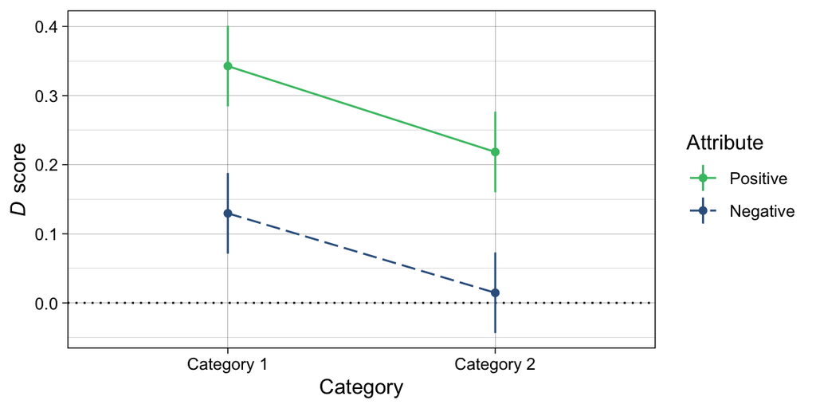

```r
fit_1 <- lmer(D ~ trial_type + (1 | Domain) + (1 | unique_id),
              data = data_long_known_stimuli)

#tab_model(fit_1, digits = 3)

data_generic_pattern <- summary(emmeans(fit_1, 1 ~ trial_type)) |>
  as.data.frame() |>
  rename(D_mean = emmean, D_ci_lower = lower.CL, D_ci_upper = upper.CL) |>
  mutate(Type = c("Generic pattern", "Generic pattern", "Generic pattern", "Generic pattern"))

plot_generic_pattern <-
  data_generic_pattern %>%
  separate(trial_type, into = c("Category", "Attribute"), sep = "\n") %>%
  mutate(Attribute = recode(Attribute,
                            "positive" = "Positive",
                            "negative" = "Negative"),
         Attribute = fct_relevel(Attribute, "Positive", "Negative"),
         D_mean = ifelse(Category == "Category 2", D_mean*-1, D_mean),
         D_ci_lower = ifelse(Category == "Category 2", D_ci_lower*-1, D_ci_lower),
         D_ci_upper = ifelse(Category == "Category 2", D_ci_upper*-1, D_ci_upper)) %>%
  ggplot(aes(Category, D_mean, color = Attribute)) +
  geom_hline(yintercept = 0, linetype = "dotted") +
  geom_point() +
  geom_line(aes(group = Attribute,
                linetype = Attribute,
                color = Attribute)) +
  geom_linerange(aes(ymin = D_ci_lower,
                     ymax = D_ci_upper,
                     group = Attribute,
                     color = Attribute)) +
  scale_color_viridis_d(begin = 0.3, end = 0.7, direction = -1) +
  ylab(expression(paste(italic("D"), " score"))) +
  scale_linetype_manual(values = c("solid", "longdash"))+
  theme_linedraw()

plot_generic_pattern
```

```r
ggsave("plots/plot_generic_pattern_2.pdf",
       plot = plot_generic_pattern,
       width = 7,
       height = 4,
       units = "in")

#write_rds(plot_generic_pattern, "models/plot_generic_pattern.rds")
```

## Compare domains

### Plot

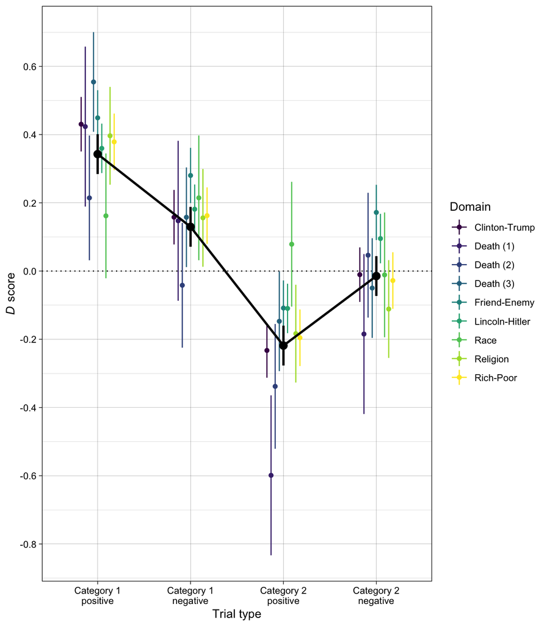

```r
# fit model
fit_2 <-
  aov(D ~ trial_type * Domain + Error(unique_id / trial_type),
      data = data_long_known_stimuli,
      contrasts = list(trial_type = "contr.sum",
                       Domain = "contr.sum"))

# extract marginal means
data_emms_2 <- summary(emmeans(fit_2, 1 ~ trial_type:Domain))

plot_domains <-
  ggplot() +
  geom_hline(yintercept = c(0), linetype = "dotted") +
  geom_linerange(data = data_emms_2,
                 aes(x = trial_type,
                     ymax = lower.CL,
                     ymin = upper.CL,
                     colour = Domain),
                 position = position_dodge(width = .4)) +
  geom_point(
    data = data_emms_2, aes(x = trial_type, y = emmean, colour = Domain),
    #aes(shape = Domain),
    size = 1.5,
    position = position_dodge(width = .4)
  ) +
  geom_line(
    data = data_emms_2, aes(x = trial_type, y = emmean, colour = Domain),
    #aes(group = Domain),
    position = position_dodge(width = .4)
  ) +
  geom_linerange(data = data_generic_pattern,
                 aes(x = trial_type,
                     y = D_mean,
                     group = Type,
                     ymin = D_ci_lower,
                     ymax = D_ci_upper),
                 size = 1) +
  geom_line(data = data_generic_pattern,
            aes(x = trial_type, y = D_mean, group = Type),
            size = 1) +
  geom_point(data = data_generic_pattern,
             aes(x = trial_type, y = D_mean, group = Type),
             size = 3) +
  scale_y_continuous(breaks = scales::breaks_width(.20)) +
  ylab(expression(paste(italic("D"), " score"))) +
  xlab("Trial type") +
  theme_linedraw() +
  scale_color_viridis_d()

plot_domains
```

```r
#write_rds(plot_domains, "models/plot_domains.rds")
```

### Effect sizes

Comparison of effect sizes: eta squared, partial eta squared, and generalized eta squared.

```r
fit <- data_long_known_stimuli %>%
  # reshape so that participants are sampled between bootstraps
  select(unique_id, Domain, trial_type, D) %>%
  spread(trial_type, D) %>%
  rename(tt1 = `Category 1\npositive`,
         tt2 = `Category 1\nnegative`,
         tt3 = `Category 2\npositive`,
         tt4 = `Category 2\nnegative`) %>%
  # undo reshaping
  gather(trial_type, D, c("tt1", "tt2", "tt3", "tt4")) %>%
  # fit anova
  ez::ezANOVA(data     = .,
              dv       = D,
              within   = trial_type,
              between  = Domain,
              wid      = unique_id,
              type     = 3,
              detailed = TRUE)

# eta squared and generalized eta squared
results_etasq <-
  fit$ANOVA %>%
  mutate(etasq = SSn / sum(SSn)) %>%
  select(Effect, etasq)

# partial eta squared
results_petasq_and_getasq <-
  anova_out_no_rounding(fit,
                        etasq = "partial",
                        sph.cor = "no",
                        print = FALSE)$ANOVA_RESULTS %>%
  mutate(petasq = as.numeric(as.character(petasq)),
         getasq = as.numeric(as.character(getasq))) %>%
  select(Effect, petasq, getasq)

# combine
results_proportion_of_variance_effect_size <-
  results_etasq %>%
  left_join(results_petasq_and_getasq, by = "Effect")
```

#### Bootstrapped 90% confidence intervals

Note that 90% confidence intervals should be calculated rather than 95% as eta squared and its variants are necessarily positive.

```r
if (file.exists("models/boot_fits_domains.rds")) {

  boot_fits_domains <- read_rds("models/boot_fits_domains.rds")

} else {

  # create bootstraps using out of bag method. makes a df with values that are collapsed dfs.
  boots <- data_long_known_stimuli %>%
    # reshape so that participants are sampled between bootstraps
    select(unique_id, Domain, trial_type, D) %>%
    spread(trial_type, D) %>%
    rename(tt1 = `Category 1\npositive`,
           tt2 = `Category 1\nnegative`,
           tt3 = `Category 2\npositive`,
           tt4 = `Category 2\nnegative`) %>%
    # create bootstraps
    bootstraps(times = n_boots)

  # analysis workflow to be bootstrapped
  helper_function <- function(split) {

    fit_anova <- analysis(split) %>%
      # undo reshaping
      gather(trial_type, D, c("tt1", "tt2", "tt3", "tt4")) %>%
      # fit anova
      ez::ezANOVA(data     = .,
                  dv       = D,
                  within   = trial_type,
                  between  = Domain,
                  wid      = unique_id,
                  type     = 3,
                  detailed = TRUE)

    # eta squared and generalized eta squared
    results_etasq <-
      fit_anova$ANOVA %>%
      mutate(etasq = SSn / sum(SSn)) %>%
      select(Effect, etasq)

    # partial eta squared
    results_petasq_and_getasq <-
      anova_out_no_rounding(fit_anova,
                            etasq = "partial",
                            sph.cor = "no",
                            print = FALSE)$ANOVA_RESULTS %>%
      mutate(petasq = as.numeric(as.character(petasq)),
             getasq = as.numeric(as.character(getasq))) %>%
      select(Effect, petasq, getasq)

    # combine
    results_proportion_of_variance <-
      left_join(results_etasq, results_petasq_and_getasq, by = "Effect")

    return(results_proportion_of_variance)
  }

  # apply to each bootstrap
  boot_fits_domains <- boots %>%
    mutate(fit = furrr::future_map(splits, helper_function)) %>%
    unnest(fit) %>%
    select(-splits)

  write_rds(boot_fits_domains, "models/boot_fits_domains.rds")

}

# boot_fits_domains %>%
#   filter(Effect != "(Intercept)") %>%
#   gather(key, value, c(etasq, petasq, getasq)) %>%
#   ggplot(aes(value)) +
#   geom_density(adjust = 1) +
#   facet_wrap(~ Effect + key, scales = "free", ncol = 3)

boot_estimates_domain <- boot_fits_domains %>%
  group_by(Effect) %>%
  dplyr::summarize(etasq_se  = sd(etasq),
                   petasq_se = sd(petasq),
                   getasq_se = sd(getasq))

# .95 for 90% intervals, as its .05 each side
critical_value <- qnorm(0.95, mean = 0, sd = 1, lower.tail = TRUE)

results_proportion_of_variance <-
  results_proportion_of_variance_effect_size %>%
  left_join(boot_estimates_domain, by = "Effect") %>%
  mutate(etasq_ci_lower  = etasq - etasq_se*critical_value,
         etasq_ci_upper  = etasq + etasq_se*critical_value,
         petasq_ci_lower = petasq - petasq_se*critical_value,
         petasq_ci_upper = petasq + petasq_se*critical_value,
         getasq_ci_lower = getasq - getasq_se*critical_value,
         getasq_ci_upper = getasq + getasq_se*critical_value) %>%
  select(Effect,
         etasq, etasq_ci_lower, etasq_ci_upper,
         petasq, petasq_ci_lower, petasq_ci_upper,
         getasq, getasq_ci_lower, getasq_ci_upper, getasq_se)

results_proportion_of_variance %>%
  round_df(3) %>%
  kable() %>%
  kable_classic(full_width = FALSE)
```

| Effect | etasq | etasq_ci_lower | etasq_ci_upper | petasq | petasq_ci_lower | petasq_ci_upper | getasq | getasq_ci_lower | getasq_ci_upper | getasq_se |
| --- | --- | --- | --- | --- | --- | --- | --- | --- | --- | --- |
| (Intercept) | 0.035 | 0.006 | 0.063 | 0.021 | 0.004 | 0.039 | 0.007 | 0.001 | 0.013 | 0.004 |
| Domain | 0.109 | 0.060 | 0.159 | 0.064 | 0.036 | 0.093 | 0.023 | 0.012 | 0.033 | 0.006 |
| trial_type | 0.738 | 0.678 | 0.798 | 0.192 | 0.155 | 0.229 | 0.136 | 0.108 | 0.164 | 0.017 |
| Domain:trial_type | 0.118 | 0.074 | 0.161 | 0.037 | 0.022 | 0.051 | 0.024 | 0.015 | 0.034 | 0.006 |

### Hypothesis tests

A common way to assess whether for differences between two estimates is to assess for non overlap between their confidence intervals. However, it has been repeatedly pointed out that this is less than ideal: there are situations where confidence intervals overlap slightly and yet the difference in means is significant.

Cornell Statistical Consulting Unit (2008) [Overlapping Confidence Intervals and Statistical Significance](https://cscu.cornell.edu/wp-content/uploads/73_ci.pdf) argue this clearly. From their whitepaper:

The null hypothesis of zero mean difference is rejected when

$|x_1 - x_2| > t \times \sqrt{SE_1^2 + SE_2^2}$

The individual confidence intervals do not overlap when

$|x_1 - x_2| > t \times (SE_1 + SE_2)$

It can be shown that the following is always true:

$\sqrt{SE_1^2 + SE_2^2} \le (SE_1 + SE_2)$

This means that as $|x_1 - x_2|$ increases there will be a point at which there is a significant difference between the means, but where the confidence intervals still overlaps. I.e., non overlapping confidence intervals indicate differences, but partially overlapping intervals do not exclude that there being differences.

As such, it is more appropriate and liberal to test for differences between pairs of estimates based on the CI of the difference scores rather than the non-overlap of intervals of the pair of estimates.

```r
# method from https://cscu.cornell.edu/wp-content/uploads/73_ci.pdf

data_geta_wrangled <- results_proportion_of_variance |>
  filter(Effect != "(Intercept)") |>
  select(Effect, getasq, getasq_se) |>
  pivot_wider(names_from = "Effect",
              values_from = c("getasq", "getasq_se")) |>
  janitor::clean_names() |>
  select(trialtype_est = getasq_trial_type,
         trialtype_se = getasq_se_trial_type,
         domain_est = getasq_domain,
         domain_se = getasq_se_domain,
         interaction_est = getasq_domain_trial_type,
         interaction_se = getasq_se_domain_trial_type)

data_geta_wrangled |>
  mutate(trialtype_domain_est = trialtype_est - domain_est,
         trialtype_interaction_est = trialtype_est - interaction_est,

         trialtype_domain_se = sqrt(trialtype_se^2 + domain_se^2),
         trialtype_interaction_se = sqrt(trialtype_se^2 + interaction_se^2),

         trialtype_domain_z = trialtype_domain_est / trialtype_domain_se,
         trialtype_interaction_z = trialtype_interaction_est / trialtype_interaction_se,

         trialtype_domain_p = pnorm(trialtype_domain_z, lower.tail = FALSE),
         trialtype_interaction_p = pnorm(trialtype_interaction_z, lower.tail = FALSE)) |>
  select(trialtype_domain_z,
         trialtype_domain_p,
         trialtype_interaction_z,
         trialtype_interaction_p) |>
  mutate(trialtype_domain_z = janitor::round_half_up(trialtype_domain_z, 1),
         trialtype_interaction_z = janitor::round_half_up(trialtype_interaction_z, 1))
```

```
## # A tibble: 1 × 4
##   trialtype_domain_z trialtype_domain_p trialtype_interaction_z trialtype_inte…¹
##                <dbl>              <dbl>                   <dbl>            <dbl>
## 1                6.3           1.80e-10                     6.2         2.38e-10
## # … with abbreviated variable name ¹trialtype_interaction_p
```

### Plot

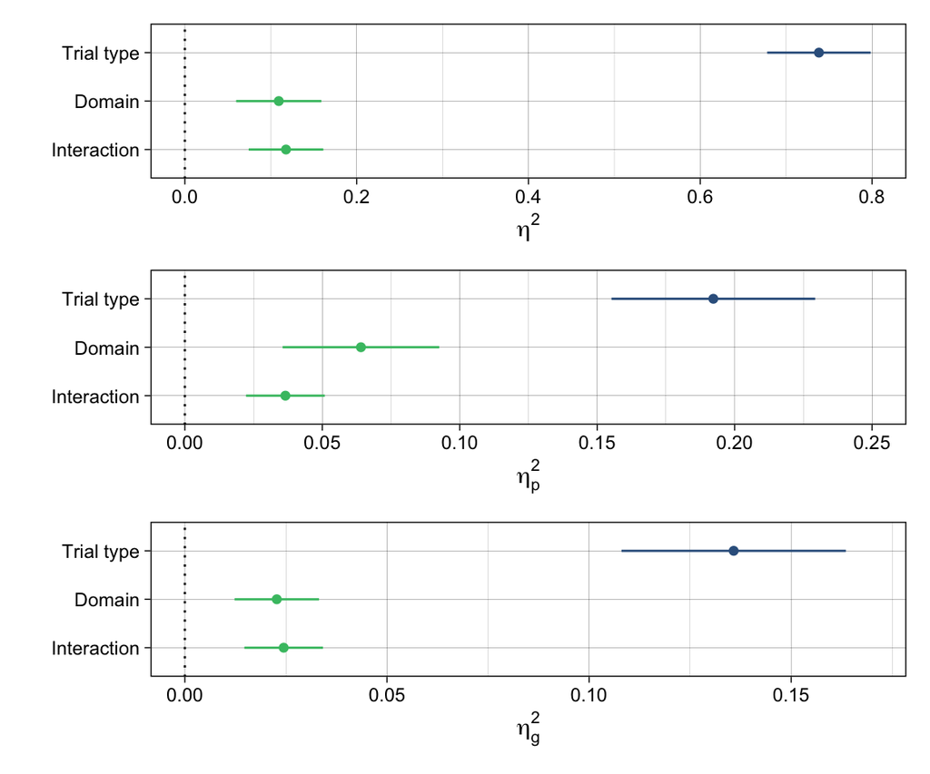

```r
# plots
data_for_plotting_domains <- results_proportion_of_variance %>%
  filter(Effect != "(Intercept)") %>%
  mutate(Effect = recode(Effect,
                         "trial_type" = "Trial type",
                         "Domain" = "Domain",
                         "Domain:trial_type" = "Interaction"),
         Effect = fct_relevel(Effect, "Interaction", "Domain", "Trial type"),
         color = ifelse(Effect == "Trial type", FALSE, TRUE))

p1 <-
  ggplot(data_for_plotting_domains, aes(Effect, etasq, color = color)) +
  geom_point() +
  geom_linerange(aes(ymin = etasq_ci_lower, ymax = etasq_ci_upper)) +
  scale_color_viridis_d(begin = 0.3, end = 0.7) +
  coord_flip() +
  ylim(0, .8) +
  theme_linedraw() +
  geom_hline(yintercept = 0, linetype = "dotted") +
  ylab(bquote(eta^2)) +
  xlab("") +
  theme(legend.position = "none")

p2 <-
  ggplot(data_for_plotting_domains, aes(Effect, petasq, color = color)) +
  geom_point() +
  geom_linerange(aes(ymin = petasq_ci_lower, ymax = petasq_ci_upper)) +
  scale_color_viridis_d(begin = 0.3, end = 0.7) +
  coord_flip() +
  ylim(0, .25) +
  theme_linedraw() +
  geom_hline(yintercept = 0, linetype = "dotted") +
  ylab(bquote(eta[p]^2)) +
  xlab("") +
  theme(legend.position = "none")

p3 <-
  ggplot(data_for_plotting_domains, aes(Effect, getasq, color = color)) +
  geom_point() +
  geom_linerange(aes(ymin = getasq_ci_lower, ymax = getasq_ci_upper)) +
  scale_color_viridis_d(begin = 0.3, end = 0.7) +
  coord_flip() +
  ylim(0, .17) +
  theme_linedraw() +
  geom_hline(yintercept = 0, linetype = "dotted") +
  ylab(bquote(eta[g]^2)) +
  xlab("") +
  theme(legend.position = "none")

plot_effect_sizes <- p1 + p2 + p3 + plot_layout(ncol = 1)

plot_effect_sizes
```

```r
ggsave("plots/plot_effect_sizes.pdf",
       plot = plot_effect_sizes,
       width = 4,
       height = 4.5,
       units = "in")

#write_rds(plot_effect_sizes, "models/plot_effect_sizes.rds")
```

## Compare known-word vs non-word IRAPs

### Plot

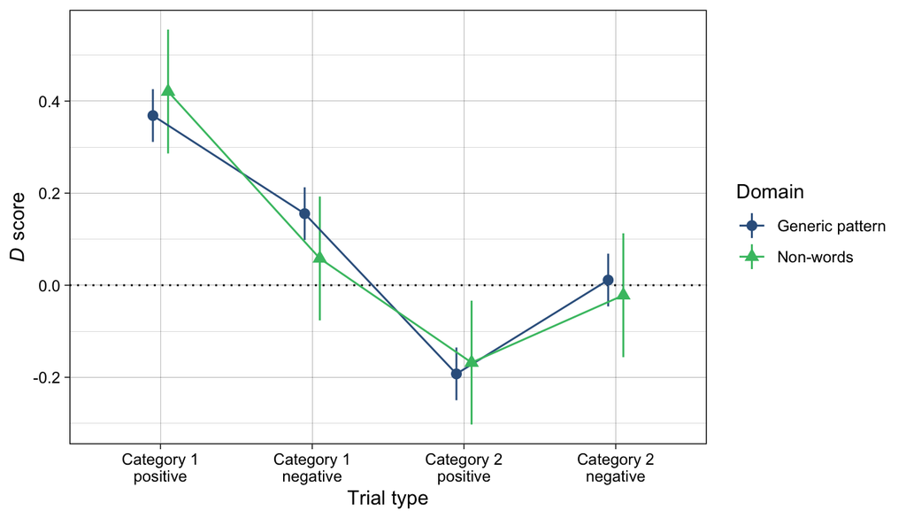

```r
# fit model
fit_3 <- data_long |>
  mutate(Domain = ifelse(Domain != "Non-words", "Generic pattern", "Non-words")) %>%
  aov(D ~ trial_type * Domain + Error(unique_id / trial_type),
      data = .,
      contrasts = list(trial_type = "contr.sum",
                       Domain = "contr.sum"))

# extract marginal means
data_emms_3 <- summary(emmeans(fit_3, 1 ~ trial_type:Domain))

plot_stimuli <-
  ggplot() +
  geom_hline(yintercept = c(0), linetype = "dotted") +
  geom_linerange(data = data_emms_3,
                 aes(x = trial_type,
                     ymax = lower.CL,
                     ymin = upper.CL,
                     colour = Domain),
                 position = position_dodge(width = .2)) +
  geom_line(
    data = data_emms_3, aes(x = trial_type, y = emmean, colour = Domain, group = Domain),
    position = position_dodge(width = .2)
  ) +
  geom_point(
    data = data_emms_3, aes(x = trial_type, y = emmean, colour = Domain, shape = Domain),
    size = 2.5,
    position = position_dodge(width = .2)
  ) +
  ylab(expression(paste(italic("D"), " score"))) +
  xlab("Trial type") +
  theme_linedraw() +
  scale_color_viridis_d(begin = 0.3, end = 0.7)

plot_stimuli
```

```r
# combine plots
plot_generic_pattern_1 <- plot_domains + plot_stimuli + plot_layout(ncol = 1)

ggsave("plots/plot_generic_pattern_1.pdf",
       plot = plot_generic_pattern_1,
       width = 7,
       height = 8,
       units = "in")
```

### Hypothesis test

Assess presence of IRAP effects on non-words IRAP

```r
data_long_unknown_stimuli |>
  pivot_wider(names_from = trial_type,
              values_from = D) |>
  janitor::clean_names() |>
  rowwise() |>
  mutate(positive = mean(c(category_1_positive, category_2_positive*-1)),
         negative = mean(c(category_1_negative, category_2_negative*-1))) |>
  ungroup() |>
  select(-category_1_positive, -category_2_positive,
         -category_1_negative, -category_2_negative) |>
  pivot_longer(cols = c(positive, negative),
               names_to = "trial_type",
               values_to = "D") |>
  group_by(trial_type) %>%
  do(tidy(t.test(.$D))) |>
  select(trial_type, mean = estimate, t = statistic, df = parameter, p = p.value) |>
  mutate(mean = janitor::round_half_up(mean, digits = 2),
         t = janitor::round_half_up(t, digits = 2)) |>
  kable() |>
  kable_classic(full_width = FALSE)
```

| trial_type | mean | t | df | p |
| --- | --- | --- | --- | --- |
| negative | 0.04 | 0.65 | 22 | 0.5231529 |
| positive | 0.29 | 5.99 | 22 | 0.0000050 |

# Recommendations

Valid and invalid inferences using a hypothetical data for a commonly employed design within IRAP research (i.e., comparisons between two known groups).

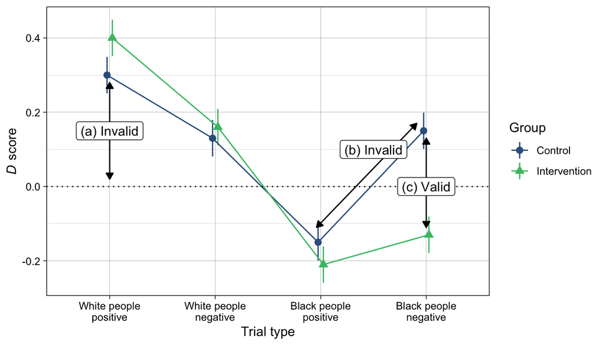

```r
# data
data_recommendations <-
  data.frame(Group = c("Intervention","Control","Intervention","Control",
                       "Intervention","Control","Intervention","Control"),
             D = c(0.2*2, 0.15*2, 0.08*2, 0.065*2, -0.105*2, -0.075*2, -0.065*2, 0.075*2),
             trial_type = c("White people\npositive",
                            "White people\npositive",
                            "White people\nnegative",
                            "White people\nnegative",
                            "Black people\npositive",
                            "Black people\npositive",
                            "Black people\nnegative",
                            "Black people\nnegative"),
             SE = c(0.025, 0.025, 0.025, 0.025, 0.025, 0.025, 0.025, 0.025)) %>%
  dplyr::mutate(trial_type = forcats::fct_relevel(as.factor(trial_type),
                                                  "White people\npositive",
                                                  "White people\nnegative",
                                                  "Black people\npositive",
                                                  "Black people\nnegative"))

# plot recommendations
plot_recommendations <-
  ggplot(data_recommendations, aes(x = trial_type, y = D, colour = Group)) +
  geom_linerange(aes(ymax = D + (1.96*SE),
                     ymin = D + (-1.96*SE)),
                 position = position_dodge(width = .1)) +
  geom_point(aes(shape = Group),
             size = 2.5,
             position = position_dodge(width = .1)) +
  geom_line(aes(group = Group),
            position = position_dodge(width = .1)) +
  geom_hline(yintercept = c(0), linetype = "dotted") +
  ylab(expression(paste(italic("D"), " score"))) +
  xlab("Trial type") +
  theme_linedraw() +
  geom_line(data = data.frame(x = c(1, 1), y = c(0.01*2, 0.14*2)),
            aes(x = x, y = y),
            colour = "black",
            #linetype = "dashed",
            arrow = arrow(length = unit(0.20, "cm"),
                          ends = "both",
                          type = "closed")) +
  annotate("label", x = 1, y = 0.075*2, label = "(a) Invalid") +
  geom_line(data = data.frame(x = c(2.96, 3.91), y = c(-0.055*2, 0.085*2)),
            aes(x = x, y = y),
            colour = "black",
            #linetype = "dashed",
            arrow = arrow(length = unit(0.20, "cm"),
                          ends = "both",
                          type = "closed")) +
  annotate("label", x = 3.5, y = 0.05*2, label = "(b) Invalid") +
  geom_line(data = data.frame(x = c(4, 4), y = c(-0.0551*2, 0.065*2)),
            aes(x = x, y = y),
            colour = "black",
            #linetype = "dashed",
            arrow = arrow(length = unit(0.20, "cm"),
                          ends = "both",
                          type = "closed")) +
  annotate("label", x = 4, y = 0, label = "(c) Valid") +
  scale_color_viridis_d(begin = 0.3, end = 0.7) +
  scale_y_continuous(breaks = scales::breaks_width(.20))

plot_recommendations
```

```r
ggsave("plots/plot_recommendations.pdf",
       plot = plot_recommendations,
       width = 7,
       height = 4,
       units = "in")

#write_rds(plot_recommendations, "models/plot_recommendations.rds")
```